# Midterm

Dolores Chu

10/24/2019

##### The dataset on American College and University Rankings contains information on 1302 American colleges and universities offering an undergraduate program. For each university, there are 17 measurements, including continuous measurements (such as tuition and graduation rate) and categorical measurements (such as location by state and whether it is a private or public school).

##### Note that many records are missing some measurements.

Read in data

```r
university_data <- read.csv("Universities.csv")
library(caret)
library(tidyverse)
library(dplyr)
```

##### a. Remove all records with missing measurements from the dataset.

```r
university_data <- na.omit(university_data)
```

##### b. For all the continuous measurements, run K-Means clustering. Make sure to normalize the measurements. How many clusters seem reasonable for describing these data? What was your optimal K?

It seems that k=2 is the optimal solution.

```r
university_data_cont <- university_data [, 4:20]
norm_model <- preProcess(university_data_cont, method = "range")
udata_cont_norm <- predict(norm_model, university_data_cont)
library(factoextra)
```

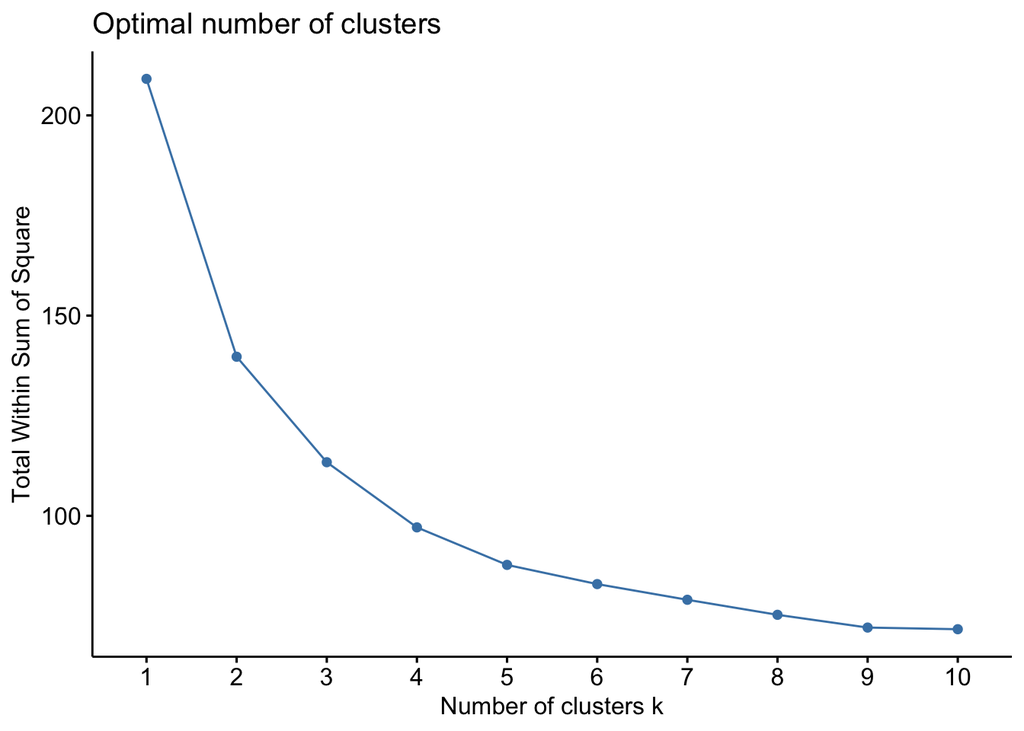

```r
fviz_nbclust(udata_cont_norm, kmeans, method = "wss")
```

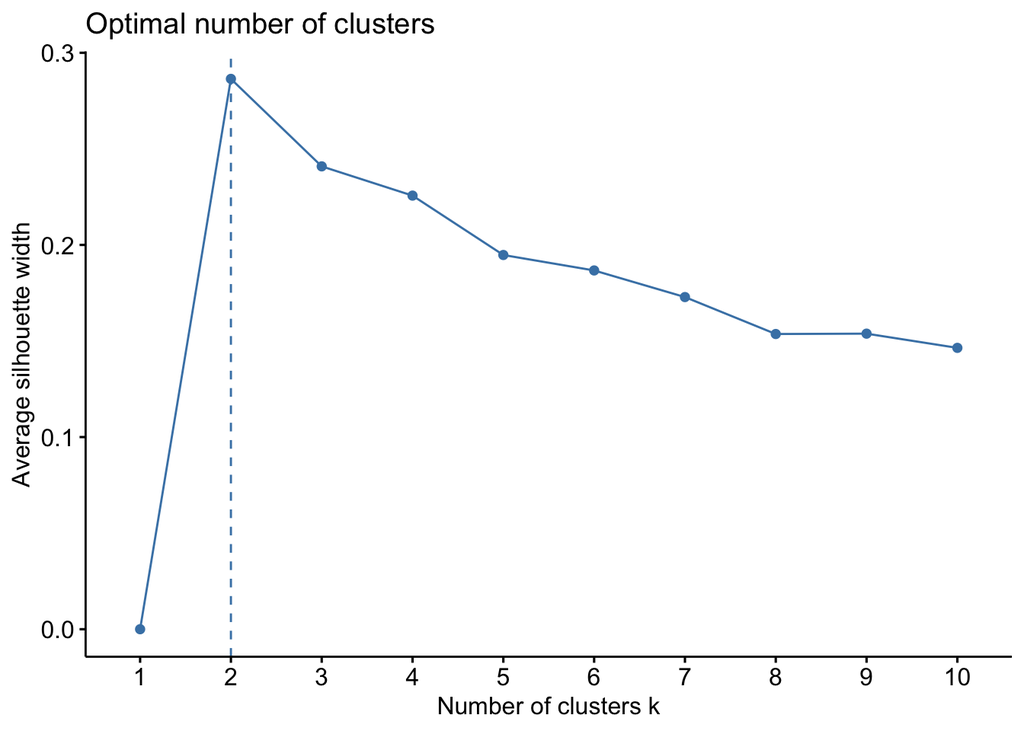

```r
fviz_nbclust(udata_cont_norm, kmeans, method = "silhouette")
```

##### c. Compare the summary statistics for each cluster and describe each cluster in this context (e.g., “Universities with high tuition, low acceptance rate…”).

Cluster 1: Universities with more new students enrolled, less new student from top 10 or 25 (college? high school?), more full-time and part-time undergrad students, tuitions are significantly lower, less room(?) and board (?), more personale; less of the falcuty memebrs of these universities have PHD degrees, and the student/faculty ratio is higher; finally, the graduation rates of these universities are lower.  
Cluster 2: in terms of students, these universities have less new students enrolled, and more students from top 10 or 25, and less part-time and full-time undergrad students. Tuitions of these univesities are significantly higher. These are universities with more room and board (?). In terms of staff and faculty, these universities have less estimated personale. More of their faculties have PHD degrees, and the student/faculty ratios are lower. Finally, the graduation rates of these universities are higher.

```r
set.seed(123)
k2 <- kmeans(udata_cont_norm, centers = 2, nstart = 25)
k2$centers
```

```
##   X..appli..rec.d X..appl..accepted X..new.stud..enrolled
## 1      0.06195842        0.07853299            0.13179292
## 2      0.06732781        0.07224437            0.09557747
##   X..new.stud..from.top.10. X..new.stud..from.top.25. X..FT.undergrad
## 1                 0.1950027                 0.4122914      0.12484864
## 2                 0.4368421                 0.6839712      0.07263523
##   X..PT.undergrad in.state.tuition out.of.state.tuition      room
## 1      0.04757105        0.2846742            0.3624967 0.3191163
## 2      0.01753801        0.7359763            0.7351530 0.4801809
##       board add..fees estim..book.costs estim..personal.. X..fac..w.PHD
## 1 0.3398633 0.1182061         0.2031066         0.1858653     0.6193514
## 2 0.4938315 0.1068234         0.2052644         0.1216118     0.8008469
##   stud..fac..ratio Graduation.rate
## 1        0.4833015       0.4146318
## 2        0.3312475       0.6210802
```

##### d. Use the categorical measurements that were not used in the analysis (State and Private/Public) to characterize the different clusters. Is there any relationship between the clusters and the categorical information?

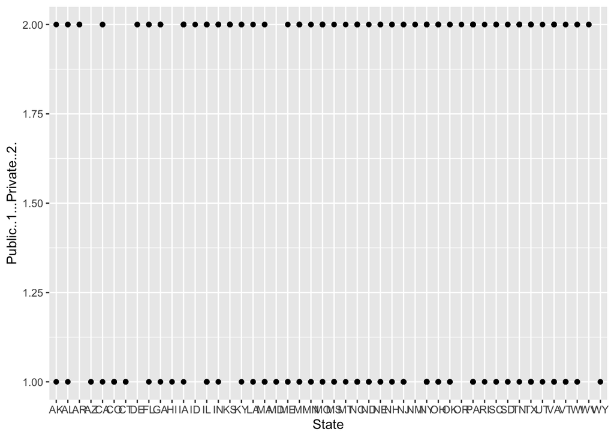

```r
university_data$cluster_label <- k2$cluster
library(ggplot2)
ggplot(university_data[university_data$cluster_label==1, ], aes(x = State, y = Public..1...Private..2.)) + geom_point()
```

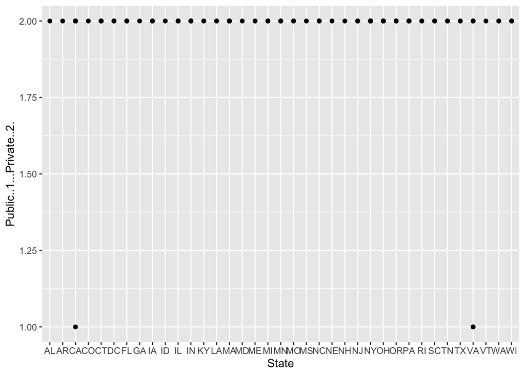

```r
ggplot(university_data[university_data$cluster_label==2, ], aes(x = State, y = Public..1...Private..2.)) + geom_point()
```

##### e. What other external information can explain the contents of some or all of these clusters?

Cluster 2 has more prestigious universities (private and public) such as Harvard University, Columbia University, Boston University, University of Chicago, etc.

```r
Cluster_1 <- university_data[university_data$cluster_label == 1, ]
Cluster_1$College.Name
```

```
##   [1] Alaska Pacific University
##   [2] University of Alaska Southeast
##   [3] Huntingdon College
##   [4] Talladega College
##   [5] University of Alabama at Birmingham
##   [6] Arkansas College (Lyon College)
##   [7] John Brown University
##   [8] Harding University
##   [9] Northern Arizona University
##  [10] University of Arizona
##  [11] California Polytechnic-San Luis
##  [12] Southern California College
##  [13] Concordia University
##  [14] Adams State College
##  [15] Fort Lewis College
```

[output cut: 283 more lines]

```r
Cluster_2 <- university_data[university_data$cluster_label == 2, ]
Cluster_2$College.Name
```

```
##   [1] Birmingham-Southern College
##   [2] Hendrix College
##   [3] Claremont McKenna College
##   [4] Harvey Mudd College
##   [5] Pitzer College
##   [6] Scripps College
##   [7] Occidental College
##   [8] Fresno Pacific College
##   [9] Pepperdine University
##  [10] St. Mary's College of California
##  [11] University of San Francisco
##  [12] University of Southern California
##  [13] Westmont College
##  [14] Loyola Marymount University
##  [15] Colorado College
```

[output cut: 160 more lines]

##### f. Consider Tufts University, which is missing some information. Compute the Euclidean distance of this record from each of the clusters that you found above (using only the measurements that you have). Which cluster is it closest to? Impute the missing values for Tufts by taking the average of the cluster on those measurements.

Calculating the Euclidean distance of Tufts University using measurements we have.Since the Euclidean distance between Tufts and cluster 1 is greater than that of cluster 2, Tufts belong to cluster 2.

```r
university_data <- read.csv("Universities.csv")
university_data[university_data$College.Name == "Tufts University", ]
```

```
##         College.Name State Public..1...Private..2. X..appli..rec.d
## 476 Tufts University    MA                       2            7614
##     X..appl..accepted X..new.stud..enrolled X..new.stud..from.top.10.
## 476              3605                  1205                        60
##     X..new.stud..from.top.25. X..FT.undergrad X..PT.undergrad
## 476                        90            4598              NA
##     in.state.tuition out.of.state.tuition room board add..fees
## 476            19701                19701 3038  2930       503
##     estim..book.costs estim..personal.. X..fac..w.PHD stud..fac..ratio
## 476               600               928            99             10.3
##     Graduation.rate
## 476              92
```

```r
university_data_cont <- university_data[, 4:20]
university_data_cont_n <- scale(university_data_cont)
Tufts <- university_data_cont_n[476,]
centroids <- k2$centers
DF_1 <- rbind(Tufts, centroids[1,])
DF_2 <- rbind(Tufts, centroids[2,])
distance_1 <- get_dist(DF_1)
distance_2 <- get_dist(DF_2)
distance_1 > distance_2
```

```
## [1] TRUE
```

Impute missing valuess for Tufts by taking the average of the cluster on those measurements.

```r
Tufts$X..PT.undergrad <-centroids[2, 7]
Tufts
```

```
## $X..appli..rec.d
## [1] 1.372653
##
## $X..appl..accepted
## [1] 0.7705108
##
## $X..new.stud..enrolled
## [1] 0.4817205
##
## $X..new.stud..from.top.10.
## [1] 1.874556
##
## $X..new.stud..from.top.25.
## [1] 1.803047
##
## $X..FT.undergrad
## [1] 0.1992003
##
## $X..PT.undergrad
## [1] 0.01753801
##
## $in.state.tuition
## [1] 2.207062
##
## $out.of.state.tuition
## [1] 2.499321
##
## $room
## [1] 0.4547283
##
## $board
## [1] 1.313225
##
## $add..fees
## [1] 0.2364556
##
## $estim..book.costs
## [1] 0.2989274
##
## $estim..personal..
## [1] -0.6458426
##
## $X..fac..w.PHD
## [1] 1.702848
##
## $stud..fac..ratio
## [1] -0.8789855
##
## $Graduation.rate
## [1] 1.672645
```